# Projet Coinertie / Master 2 ECOMONT

Ce projet est réalisé dans le cadre du Master 2 ECOMONT et porte sur l’étude de coinertie entre un tableau de dominances végétales et un tableau rassemblant les paramètres abiotiques collectés sur 53 quadrats du site d’ARAVO en 2022 (seules les données SMOD (snow melt-out date) datent de 1997 à 1999).

# 1 Chargement des librairies

```r
library(tidyverse)
library(corrplot)
library(ade4)
library(kableExtra)
library(knitr)
library(splines)
library(DT)
library(Hmisc)
library(FactoMineR)
library(factoextra)
library(vegan)
library(RVAideMemoire)
```

# 2 Import et description des deux tableaux de données

## 2.1 Import du tableau de dominances végétales

Le tableau de dominances végétales rassemble les informations de présence/absence d’espèces en tant qu’espèces dominantes sur 53 quadrats de 1 m sur 1 m réalisés sur le site d’ARAVO.

|  | Alch.pent | Alopec.alpi | Andro.vital | Anten.dioi | Care.foet | Care.myos | Care.semp | Fest.viol | Geum.mont | Gnap.supi | Minuart.sed | Plan.alpi | Poa.alpina | Potent.aurea | Potent.crantzii | Sali.herb | Sali.serpy | Trif.alpina |
| --- | --- | --- | --- | --- | --- | --- | --- | --- | --- | --- | --- | --- | --- | --- | --- | --- | --- | --- |
| 39 | 0 | 0 | 0 | 0 | 0 | 1 | 0 | 0 | 0 | 0 | 0 | 0 | 0 | 0 | 0 | 0 | 0 | 0 |
| 66 | 0 | 0 | 0 | 0 | 0 | 1 | 0 | 0 | 0 | 0 | 0 | 0 | 0 | 0 | 0 | 0 | 0 | 0 |
| 69 | 0 | 0 | 0 | 0 | 0 | 0 | 0 | 0 | 0 | 0 | 0 | 0 | 0 | 0 | 0 | 0 | 0 | 0 |
| 93 | 0 | 0 | 0 | 0 | 0 | 0 | 0 | 0 | 0 | 0 | 0 | 0 | 0 | 0 | 0 | 0 | 0 | 0 |
| 96 | 0 | 0 | 0 | 0 | 0 | 0 | 0 | 0 | 1 | 0 | 0 | 1 | 0 | 0 | 0 | 0 | 0 | 0 |
| 99 | 0 | 0 | 0 | 0 | 0 | 0 | 0 | 0 | 0 | 0 | 0 | 0 | 0 | 0 | 0 | 0 | 0 | 0 |
| 120 | 0 | 0 | 0 | 0 | 0 | 0 | 0 | 1 | 0 | 0 | 0 | 0 | 0 | 0 | 0 | 0 | 0 | 0 |
| 123 | 0 | 0 | 0 | 0 | 0 | 0 | 0 | 0 | 0 | 0 | 0 | 1 | 0 | 1 | 0 | 0 | 0 | 0 |
| 126 | 0 | 0 | 0 | 0 | 0 | 0 | 0 | 0 | 0 | 0 | 0 | 0 | 0 | 0 | 0 | 0 | 0 | 1 |
| 129 | 0 | 0 | 0 | 0 | 0 | 0 | 0 | 0 | 1 | 0 | 0 | 0 | 0 | 0 | 0 | 0 | 0 | 0 |
| 150 | 0 | 0 | 0 | 0 | 0 | 0 | 0 | 0 | 0 | 0 | 0 | 0 | 0 | 0 | 0 | 0 | 0 | 0 |
| 153 | 0 | 0 | 0 | 0 | 0 | 0 | 0 | 0 | 0 | 0 | 0 | 0 | 1 | 0 | 0 | 0 | 0 | 0 |
| 156 | 1 | 0 | 0 | 0 | 0 | 0 | 0 | 0 | 0 | 0 | 0 | 0 | 0 | 0 | 0 | 0 | 0 | 0 |
| 159 | 0 | 0 | 0 | 0 | 0 | 0 | 0 | 0 | 0 | 0 | 0 | 0 | 1 | 0 | 0 | 0 | 0 | 0 |
| 183 | 1 | 0 | 0 | 0 | 0 | 0 | 0 | 0 | 0 | 0 | 0 | 0 | 0 | 0 | 0 | 0 | 0 | 0 |
| 186 | 0 | 0 | 0 | 0 | 0 | 0 | 0 | 0 | 0 | 0 | 0 | 0 | 1 | 0 | 0 | 0 | 0 | 0 |
| 189 | 0 | 0 | 0 | 0 | 0 | 1 | 0 | 0 | 0 | 0 | 0 | 0 | 0 | 0 | 0 | 1 | 0 | 0 |
| 315 | 0 | 0 | 0 | 0 | 0 | 1 | 0 | 0 | 0 | 0 | 0 | 0 | 0 | 0 | 0 | 0 | 0 | 0 |
| 318 | 0 | 0 | 0 | 0 | 0 | 1 | 0 | 0 | 0 | 0 | 0 | 0 | 0 | 0 | 0 | 0 | 0 | 0 |
| 612 | 0 | 0 | 0 | 0 | 0 | 0 | 0 | 0 | 0 | 0 | 1 | 1 | 0 | 0 | 0 | 0 | 0 | 0 |
| 615 | 0 | 0 | 0 | 0 | 0 | 0 | 1 | 1 | 0 | 0 | 0 | 0 | 0 | 0 | 0 | 0 | 0 | 0 |
| 618 | 0 | 0 | 0 | 0 | 0 | 0 | 0 | 0 | 0 | 0 | 0 | 0 | 0 | 0 | 0 | 0 | 0 | 0 |
| 912 | 0 | 0 | 0 | 0 | 0 | 0 | 0 | 0 | 0 | 0 | 0 | 0 | 0 | 0 | 0 | 0 | 0 | 0 |
| 915 | 0 | 0 | 0 | 0 | 0 | 0 | 0 | 0 | 1 | 0 | 0 | 0 | 0 | 0 | 1 | 1 | 0 | 0 |
| 918 | 1 | 0 | 0 | 0 | 0 | 0 | 0 | 0 | 1 | 0 | 0 | 0 | 0 | 0 | 0 | 0 | 0 | 0 |
| 1212 | 0 | 0 | 0 | 0 | 0 | 0 | 0 | 0 | 0 | 0 | 0 | 0 | 0 | 0 | 0 | 0 | 0 | 0 |
| 1218 | 0 | 0 | 0 | 0 | 0 | 0 | 0 | 0 | 0 | 1 | 0 | 1 | 0 | 0 | 0 | 0 | 1 | 0 |
| 1512 | 0 | 0 | 0 | 0 | 0 | 0 | 0 | 0 | 0 | 0 | 0 | 0 | 0 | 0 | 0 | 1 | 0 | 0 |
| 1515 | 0 | 0 | 0 | 0 | 0 | 0 | 0 | 0 | 0 | 0 | 0 | 0 | 0 | 0 | 0 | 0 | 0 | 0 |
| 1812 | 0 | 0 | 0 | 0 | 0 | 0 | 0 | 0 | 0 | 0 | 0 | 0 | 0 | 0 | 0 | 0 | 0 | 0 |
| 2112 | 0 | 0 | 0 | 0 | 0 | 1 | 0 | 0 | 0 | 1 | 0 | 1 | 0 | 1 | 0 | 0 | 0 | 0 |
| 10.51.5 | 0 | 0 | 0 | 0 | 0 | 0 | 0 | 0 | 0 | 0 | 0 | 0 | 0 | 0 | 0 | 0 | 0 | 0 |
| 10.510.5 | 0 | 0 | 1 | 0 | 0 | 1 | 0 | 0 | 0 | 0 | 0 | 0 | 0 | 0 | 0 | 0 | 0 | 0 |
| 10.513.5 | 1 | 1 | 0 | 0 | 0 | 0 | 0 | 0 | 0 | 0 | 0 | 0 | 0 | 0 | 0 | 0 | 0 | 0 |
| 10.516.5 | 0 | 0 | 0 | 0 | 0 | 0 | 0 | 0 | 0 | 0 | 0 | 0 | 0 | 0 | 0 | 1 | 0 | 0 |
| 10.54.5 | 0 | 0 | 0 | 0 | 0 | 0 | 0 | 0 | 0 | 0 | 0 | 1 | 0 | 1 | 0 | 0 | 0 | 0 |
| 10.57.5 | 0 | 0 | 0 | 0 | 0 | 0 | 0 | 0 | 0 | 0 | 1 | 1 | 0 | 0 | 0 | 0 | 0 | 0 |
| 13.51.5 | 0 | 0 | 0 | 0 | 0 | 0 | 0 | 0 | 0 | 0 | 0 | 0 | 0 | 0 | 0 | 0 | 0 | 0 |
| 13.510.5 | 1 | 0 | 0 | 0 | 1 | 0 | 0 | 0 | 0 | 0 | 0 | 0 | 0 | 0 | 0 | 0 | 0 | 0 |
| 13.513.5 | 0 | 0 | 0 | 0 | 0 | 0 | 0 | 0 | 0 | 0 | 0 | 0 | 0 | 0 | 0 | 0 | 0 | 0 |
| 13.516.5 | 0 | 0 | 0 | 0 | 0 | 0 | 0 | 0 | 0 | 0 | 0 | 0 | 0 | 0 | 0 | 1 | 0 | 0 |
| 13.54.5 | 0 | 0 | 0 | 0 | 0 | 0 | 0 | 0 | 1 | 0 | 0 | 1 | 1 | 0 | 0 | 0 | 0 | 0 |
| 13.57.5 | 0 | 0 | 0 | 0 | 0 | 0 | 0 | 0 | 0 | 0 | 1 | 1 | 0 | 1 | 0 | 0 | 0 | 0 |
| 16.510.5 | 0 | 0 | 0 | 0 | 0 | 1 | 0 | 0 | 0 | 0 | 0 | 0 | 0 | 0 | 0 | 0 | 0 | 0 |
| 16.54.5 | 0 | 1 | 0 | 0 | 0 | 0 | 0 | 0 | 0 | 0 | 0 | 0 | 0 | 1 | 0 | 0 | 0 | 0 |
| 16.57.5 | 0 | 0 | 0 | 0 | 0 | 0 | 1 | 0 | 0 | 0 | 0 | 0 | 1 | 0 | 0 | 0 | 0 | 0 |
| 4.510.5 | 0 | 0 | 0 | 0 | 0 | 0 | 0 | 0 | 0 | 0 | 0 | 1 | 0 | 1 | 0 | 0 | 0 | 1 |
| 4.516.5 | 0 | 0 | 0 | 0 | 0 | 0 | 0 | 1 | 0 | 0 | 0 | 0 | 0 | 1 | 0 | 0 | 0 | 0 |
| 4.57.5 | 0 | 0 | 0 | 0 | 0 | 0 | 0 | 0 | 0 | 0 | 0 | 0 | 0 | 0 | 0 | 0 | 0 | 0 |
| 7.513.5 | 1 | 0 | 0 | 0 | 0 | 0 | 0 | 0 | 0 | 0 | 0 | 1 | 0 | 0 | 0 | 0 | 0 | 0 |
| 7.516.5 | 0 | 0 | 0 | 0 | 0 | 0 | 0 | 0 | 0 | 0 | 0 | 1 | 0 | 0 | 0 | 0 | 0 | 0 |
| 7.54.5 | 0 | 0 | 0 | 0 | 0 | 1 | 0 | 0 | 0 | 0 | 0 | 0 | 0 | 0 | 0 | 0 | 0 | 0 |
| 7.57.5 | 0 | 1 | 0 | 0 | 0 | 0 | 0 | 0 | 1 | 0 | 0 | 0 | 0 | 0 | 0 | 0 | 0 | 0 |

*Tableau 1: Tableau des dominances végétales.*

## 2.2 Import du tableau abiotique

Le tableau abiotique rassemble les paramètres abiotiques associés aux 53 quadrats à savoir:  
-l’aspect = la direction horizontale de la pente en degrés. 0° signifie que la pente est face au Nord, 90° face à l’Est, 180° face au sud et 270° face à l’Ouest.  
-L’altitude issu du MNT (en m) via le logiciel QGIS  
-le pH du sol mesuré à l’aide d’un pHmètre  
-la teneur en eau du sol mesurée à partir d’un conductimètre (en µS/cm)  
-la pente des sites récupérée du MNT (en degrés) via le logiciel QGIS  
-le SMOD exprimé en tant qu’isoclines moyennes de la fonte des neiges en jours juliens (1 étant l’isocline de déneigement la plus précoce et 8 étant l’isocline de déneigement la plus tardive). Les dates de fonte des neiges ont été documentées à partir d’une enquête réalisée au cours des années 1997-1999. Même si les données sont antérieures aux autres données abiotiques, elles ont été conservées dans l’étude de co-inertie comme proxy de la topographie sur le terrain afin d’identifier les habitats typiques des combes à neige.

|  | Aspect | Altitude | pH | Teneur_eau | Pente | SMOD |
| --- | --- | --- | --- | --- | --- | --- |
| 39 | 139.44113 | 2669.6001 | 5.466666667 | 869 | 22.35863 | 2 |
| 66 | 163.62952 | 2658.33008 | 7.766666667 | 657 | 23.51178 | 3 |
| 69 | 162.12195 | 2654.8999 | 5.833333333 | 533 | 26.40189 | 3 |
| 93 | 134.34071 | 2653.1001 | 6.7 | 689 | 17.09617 | 3 |
| 96 | 152.88496 | 2646.12988 | 6.1 | 790 | 24.73384 | 4 |
| 99 | 169.88809 | 2643.80005 | 5.066666667 | 671 | 18.1323 | 4 |
| 120 | 75.55994 | 2651.61011 | 8 | 587 | 10.23911 | 2 |
| 123 | 163.48569 | 2645 | 5.2 | 906 | 13.3475 | 5 |
| 126 | 126.64807 | 2641.3501 | 5.2 | 740 | 15.00311 | 4 |
| 129 | 196.24901 | 2634.62988 | 4.766666667 | 790 | 14.03493 | 6 |

[output cut: 43 more lines]

Tableau 2: Tableau abiotique.

# 3 AFC du tableau des dominances végétales

## 3.1 Représentation graphique de l’AFC

Une AFC (analyse factorielle des correspondances) est réalisée sur les données associées au tableau des dominances végétales.

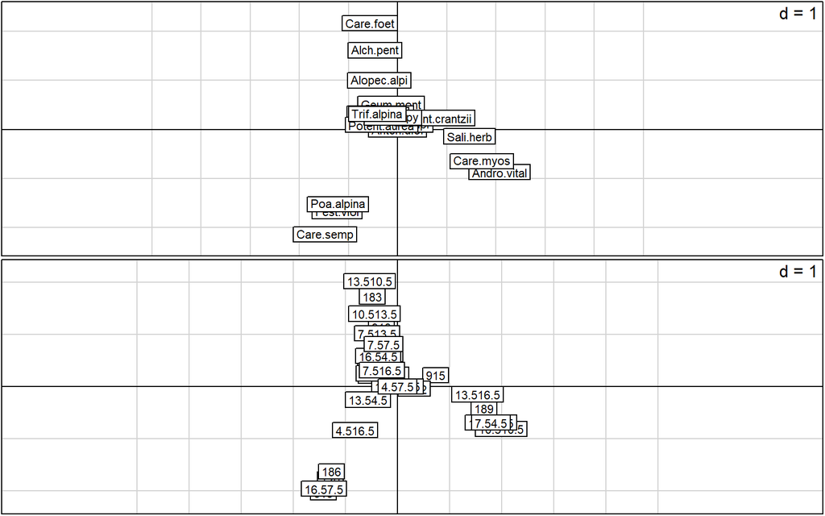

Figure 1: AFC du tableau des dominances végétales

## 3.2 Interprétation des résultats

Un étagement des espèces est observé avec les espèces résistantes au gel et au vent, plutôt typiques des crêtes ventées, situées en bas à droite du graphique telles que Carex myosuroides ou Androsace vitaliana (Varricchione et al 2022). En bas à gauche du graphique, des espèces plus mésophiles typiques des habitats situés quelques mètres sous les crêtes sont retrouvées telles que Poa alpina, Festuca violacea et Carex sempervirens (Liberati et al 2019, Varricchione et al 2022).  
Les espèces plutôt typiques des combes à neige sont situées en haut du graphique telles que Carex foetida, Alopecurus alpinus ou Alchemilla pentaphyllea (Matteodo et al 2016, Liberati et al 2019).

## 3.3 Variance expliquée par l’AFC

*Tableau 3: % de variance expliqué par l’AFC.*

|  | eigenvalue | variance.percent | cumulative.variance.percent |
| --- | --- | --- | --- |
| Dim.1 | 0.9122245 | 11.1910318 | 11.19103 |
| Dim.2 | 0.8719442 | 10.6968791 | 21.88791 |
| Dim.3 | 0.8368013 | 10.2657516 | 32.15366 |
| Dim.4 | 0.7817816 | 9.5907781 | 41.74444 |
| Dim.5 | 0.7395252 | 9.0723830 | 50.81682 |
| Dim.6 | 0.6493639 | 7.9662978 | 58.78312 |
| Dim.7 | 0.5883143 | 7.2173500 | 66.00047 |
| Dim.8 | 0.5155150 | 6.3242599 | 72.32473 |
| Dim.9 | 0.4572055 | 5.6089273 | 77.93366 |
| Dim.10 | 0.4194376 | 5.1455962 | 83.07925 |
| Dim.11 | 0.3628833 | 4.4517975 | 87.53105 |
| Dim.12 | 0.3309161 | 4.0596281 | 91.59068 |
| Dim.13 | 0.2695307 | 3.3065622 | 94.89724 |
| Dim.14 | 0.2382240 | 2.9224954 | 97.81974 |
| Dim.15 | 0.1134538 | 1.3918338 | 99.21157 |
| Dim.16 | 0.0642678 | 0.7884282 | 100.00000 |

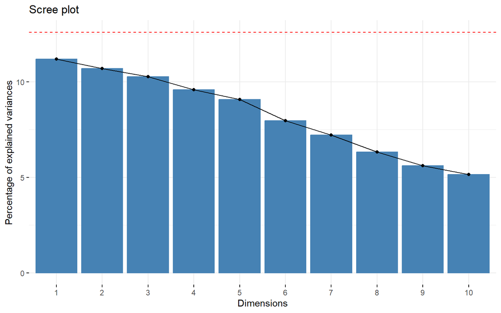

Figure 2: % de variance expliqué par l’AFC

# 4 ACP du tableau abiotique

## 4.1 Gestion des valeurs NA

La variable SMOD n’est pas transformée en facteurs similairement à la méthode appliquée au sein de la publication de Choler en 2005.  
Une valeur “NA” est présente dans le tableau pour la variable “teneur en eau”. L’une des méthodes de gestion de données NA dans une ACP (analyse en composantes principales) consiste à remplacer la valeur manquante par la moyenne de la variable.

```r
env2[is.na(env2)] <- mean(env$Teneur_eau, na.rm = T)
```

## 4.2 Représentation graphique de l’ACP

Une ACP est réalisée sur les données abiotiques. Le poids des axes de l’ACP est pondéré par le poids des axes de l’AFC pour pouvoir réaliser l’étude de coinertie des deux tableaux par la suite. En effet, la fonction “coinertia” requiert un poids des lignes identifiques pour l’AFC et l’ACP

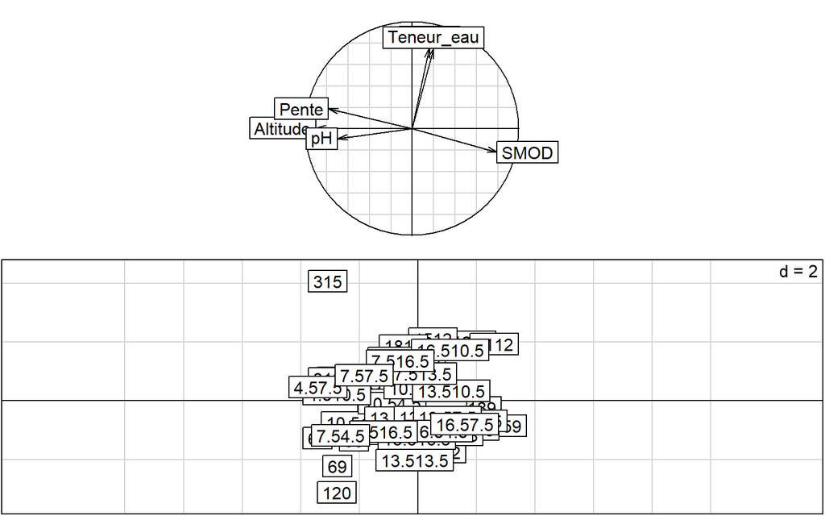

Figure 3: ACP du tableau abiotique

## 4.3 Interprétation des résultats

Les quadrats situés en bas à droite du graphique sont ceux présentant un SMOD élevé, une pente faible et une altitude faible et correspondent ainsi aux quadrats typiques des combes à neige. Les sols avec des SMOD tardifs sont généralement plus acides avec des pH faibles (Choler, 2005).  
Les quadrats situés en haut et à gauche du graphique correspondent aux crêtes ventés avec une altitude et une pente élevées, un pH élevé illustrant des sols plus basiques en raison des roches qui affleurent.  
Les quadrats situés en haut à droite correspondent aux milieux de versant avec des pentes, SMOD et altitudes moyennes.  
Les variables teneur en eau et aspect sont corrélées, indiquant que l’humidité des sols est corrélée à son exposition.

## 4.4 Variance expliquée par l’ACP

Le pourcentage de variance expliqué par l’ACP est présenté sur la figure 4. Deux axes permettent d’expliquer 64% de la variance observée. 2 axes sont retenus selon la “méthode du coude”.

*Tableau 4: % de variance expliqué par l’ACP.*

```
## Inertia information:
## Call: inertia.dudi(x = acp1)
##
## Decomposition of total inertia:
##     inertia     cum  cum(%)
## Ax1  2.6199   2.620   43.66
## Ax2  1.2316   3.851   64.19
## Ax3  0.7978   4.649   77.49
## Ax4  0.6608   5.310   88.50
## Ax5  0.4238   5.734   95.56
## Ax6  0.2662   6.000  100.00
```

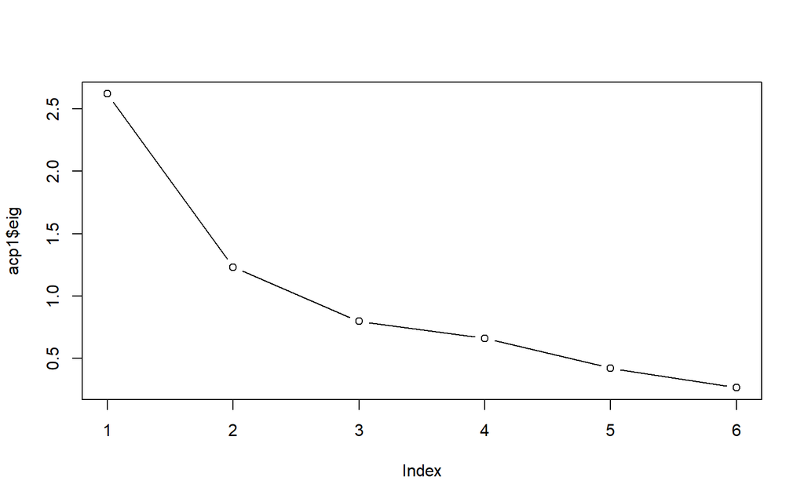

Figure 4: Variance (Eigenvalues) expliquée par l’ACP

# 5 Etude de coinertie

## 5.1 Représentation graphique de la coinertie

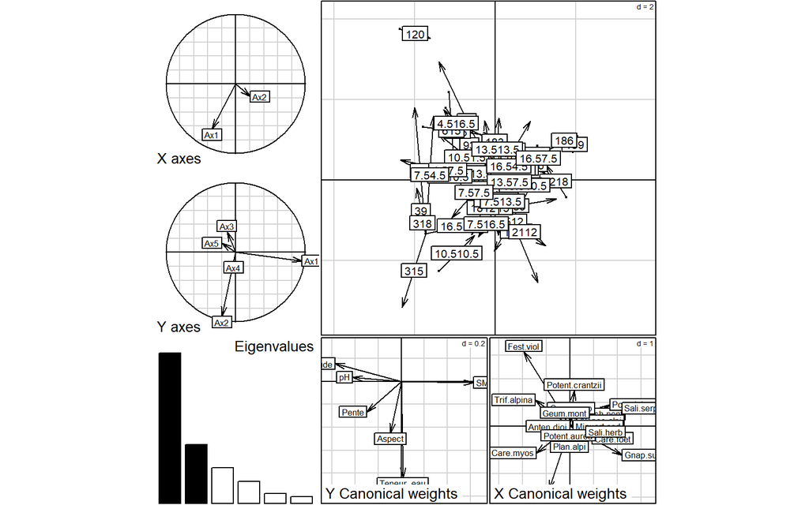

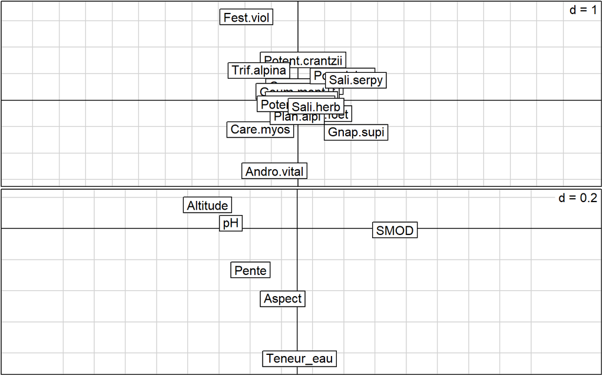

Figure 5: Coinertie entre l’AFC des dominances végétales et l’ACP des paramètres abiotiques

## 5.2 Interprétation

Les axes 1 et 2 de l’AFC des dominances végétales ont subit une rotation de 90°C. L’axe 2 de l’ACP des paramètres abiotiques a été inversé.  
Les flèches qui indiquent ou se trouvaient les quadrats en fonction de l’environnement semblent se diriger vers l’exterieur donc ce sont plutôt les variables environnementales qui discriminent les sites.  
Avant d’aller plus loin dans l’analyse, il faut vérifier qu’il y a bien une co-inertie significative via un test de Monte Carlo.

## 5.3 Test de la significativité de la coinertie

Le test est réalisé via la fonction randtest en indiquant le numéro de l’AFC dans les arguments

```r
randtest(coiner, fixed=1)
```

```
## Monte-Carlo test
## Call: randtest.coinertia(xtest = coiner, fixed = 1)
##
## Observation: 0.2091147
##
## Based on 999 replicates
## Simulated p-value: 0.215
## Alternative hypothesis: greater
##
##      Std.Obs  Expectation     Variance
## 0.7650042013 0.1873424502 0.0008099901
```

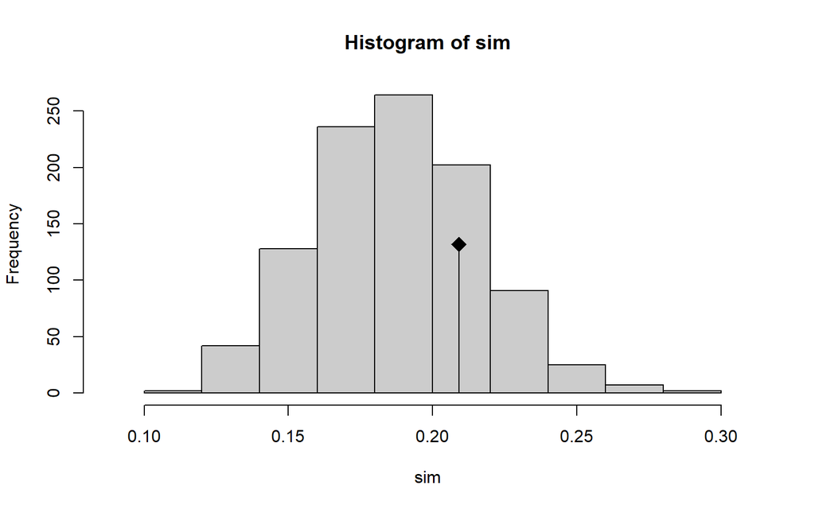

Figure 7: Significativité du test de coinertie

```r
plot(randtest(coiner, fixed=1))
```

La p value n’est pas significative (p value > 0.1) donc la coinertie entre les deux tableaux n’est pas significative. Cela signifie que les paramètres abiotiques sélectionnés ne permettent pas d’expliquer la répartition des espèces dominantes sur les quadrats concernés.